# Ejercicio 5 – Evaluación de Inversión Inmobiliaria mediante Control Difuso

En este ejercicio vamos a diseñar un sistema de control difuso para evaluar la conveniencia de invertir en un inmueble, utilizando tres variables clave: el **precio por metro cuadrado**, la **rentabilidad esperada** y la **calidad de la ubicación**. El sistema devolverá un valor numérico entre 0 y 100 que refleje el grado de conveniencia de la inversión.

Este tipo de enfoque es útil cuando los datos de entrada no tienen límites estrictos, y queremos incorporar un razonamiento más flexible y cualitativo, basado en términos como "precio barato", "ubicación buena", etc.

Usaremos la librería `scikit-fuzzy` para definir las funciones de pertenencia, aplicar las reglas y obtener el resultado final tras defuzzificar la salida.

## 1.Índice de pasos a seguir

1. **Importación de librerías y configuración inicial**
2. **Definición del universo de discurso para cada variable**
3. **Construcción de funciones de pertenencia difusas**
   - Precio por metro cuadrado
   - Rentabilidad esperada
   - Calidad de la ubicación
   - Conveniencia de inversión
4. **Visualización de las funciones de pertenencia**
5. **Definición de reglas difusas**
6. **Evaluación del sistema con los valores propuestos**
7. **Inferencia difusa y defuzzificación**
8. **Visualización gráfica del proceso de inferencia**
9. **Conclusión sobre la conveniencia de inversión**

Este flujo de trabajo nos permitirá construir un sistema de toma de decisiones interpretativo, aplicando técnicas de lógica difusa a un caso práctico del ámbito inmobiliario.

```python
# Estilo visual coherente para todo el notebook
import matplotlib.pyplot as plt
import seaborn as sns

# Aplicamos un estilo claro y profesional
sns.set_theme(style='whitegrid', palette='Set2', context='talk')

# Configuración general de matplotlib
plt.rcParams['figure.figsize'] = (10, 6)
plt.rcParams['axes.titlesize'] = 16
plt.rcParams['axes.labelsize'] = 14
plt.rcParams['legend.fontsize'] = 12
plt.rcParams['xtick.labelsize'] = 12
plt.rcParams['ytick.labelsize'] = 12
```

```
Matplotlib is building the font cache; this may take a moment.
```

## 2.Librerías utilizadas

En este ejercicio utilizaremos las siguientes librerías de Python:

- **NumPy**: para trabajar con arreglos y operaciones numéricas eficientes.
- **Matplotlib** y **Seaborn**: para la visualización de funciones de pertenencia y resultados de inferencia.
- **scikit-fuzzy (`skfuzzy`)**: para implementar el sistema de control difuso, definiendo las funciones de pertenencia, reglas e inferencia difusa.
- **IPython.display**: para mostrar gráficos y salidas organizadas dentro del notebook.

Estas librerías nos permitirán construir y representar visualmente un sistema difuso completo, paso a paso.

```python
# First, install the skfuzzy package
!pip install scikit-fuzzy

# Then load the necessary libraries
import numpy as np
import skfuzzy as fuzz
from skfuzzy import control as ctrl
from IPython.display import display
```

```
Downloading scikit_fuzzy-0.5.0-py2.py3-none-any.whl (920 kB)
   ━━━━━━━━━━━━━━━━━━━━━━━━━━━━━━━━━━━━━━━━ 920.8/920.8 kB 6.4 MB/s eta 0:00:00
```

## 3.Definición de variables y universos de discurso

A continuación definimos las variables que forman parte del sistema difuso:

**Variables de entrada (antecedentes):**

- **Precio por metro cuadrado**: de 500 a 5000 USD
- **Rentabilidad esperada (% anual)**: de 0% a 20%
- **Ubicación (calificación subjetiva)**: de 0 a 10

**Variable de salida (consecuente):**

- **Conveniencia de inversión**: de 0 a 100

Para cada variable definiremos su universo de discurso y las funciones de pertenencia correspondientes, usando funciones trapezoidales y sigmoidales según las características proporcionadas en el enunciado.

```python
# Definición de los universos de discurso
universo_precio = np.arange(500, 5001, 1)         # Precio por m²
universo_rentabilidad = np.arange(0, 20.1, 0.1)   # Rentabilidad %
universo_ubicacion = np.arange(0, 10.1, 0.1)      # Ubicación
universo_conveniencia = np.arange(0, 101, 1)      # Conveniencia (salida)

# Creamos las variables difusas
precio = ctrl.Antecedent(universo_precio, 'precio')
rentabilidad = ctrl.Antecedent(universo_rentabilidad, 'rentabilidad')
ubicacion = ctrl.Antecedent(universo_ubicacion, 'ubicacion')
conveniencia = ctrl.Consequent(universo_conveniencia, 'conveniencia')
```

### Funciones de pertenencia: Precio por metro cuadrado

Para la variable **precio por metro cuadrado**, definimos tres conjuntos difusos utilizando funciones de pertenencia trapezoidales:

- **Barato**: desde 500 hasta aproximadamente 1500 USD/m²
- **Medio**: valores intermedios entre 1200 y 3000 USD/m²
- **Caro**: a partir de 2800 hasta 5000 USD/m²

Estas funciones permiten que un mismo valor pueda pertenecer a más de un conjunto con distinto grado, lo que permite razonamientos más flexibles.

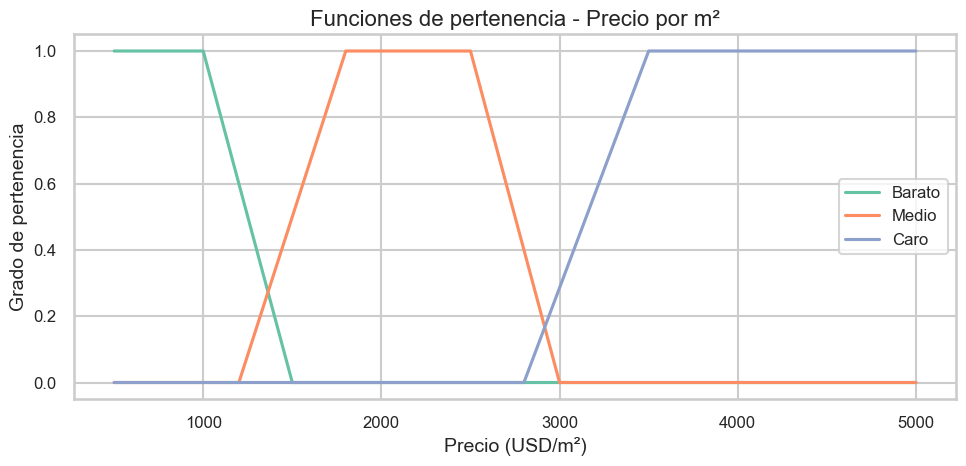

```python
# Funciones de pertenencia trapezoidales para "precio"
precio['barato'] = fuzz.trapmf(precio.universe, [500, 500, 1000, 1500])
precio['medio']  = fuzz.trapmf(precio.universe, [1200, 1800, 2500, 3000])
precio['caro']   = fuzz.trapmf(precio.universe, [2800, 3500, 5000, 5000])

# Visualización manual con matplotlib
plt.figure(figsize=(10, 5))
plt.plot(precio.universe, precio['barato'].mf, label='Barato')
plt.plot(precio.universe, precio['medio'].mf, label='Medio')
plt.plot(precio.universe, precio['caro'].mf, label='Caro')
plt.title('Funciones de pertenencia - Precio por m²')
plt.xlabel('Precio (USD/m²)')
plt.ylabel('Grado de pertenencia')
plt.legend()
plt.tight_layout()
plt.show()
```

### Funciones de pertenencia: Rentabilidad esperada

La variable **rentabilidad esperada** se define sobre el intervalo de 0% a 20% anual. Representamos dos conjuntos difusos mediante funciones de pertenencia **sigmoidales**:

- **Baja**: función sigmoidal decreciente con parámetros b=7, c=−1
- **Alta**: función sigmoidal creciente con parámetros b=10, c=1

Este tipo de función permite una transición progresiva entre "baja" y "alta", de forma que los valores intermedios pueden pertenecer parcialmente a ambos conjuntos.

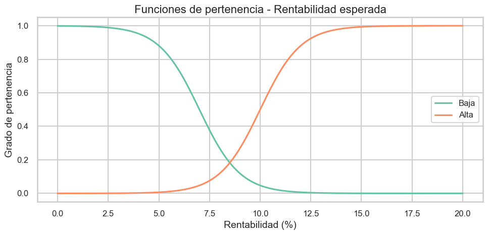

```python
# Definición de funciones de pertenencia para rentabilidad
rentabilidad['baja'] = fuzz.sigmf(rentabilidad.universe, b=7, c=-1)  # Changed a→c to c→b and a→c
rentabilidad['alta'] = fuzz.sigmf(rentabilidad.universe, b=10, c=1)  # Changed a→c to c→b and a→c

# Visualización
plt.figure(figsize=(10, 5))
plt.plot(rentabilidad.universe, rentabilidad['baja'].mf, label='Baja')
plt.plot(rentabilidad.universe, rentabilidad['alta'].mf, label='Alta')
plt.title('Funciones de pertenencia - Rentabilidad esperada')
plt.xlabel('Rentabilidad (%)')
plt.ylabel('Grado de pertenencia')
plt.legend()
plt.tight_layout()
plt.show()
```

### Funciones de pertenencia: Calidad de la ubicación

La variable **ubicación** se define en una escala subjetiva de 0 a 10. Usamos funciones trapezoidales para representar tres categorías:

- **Mala**: valores entre 0 y 4, donde los más bajos tienen pertenencia total.
- **Media**: valores intermedios, con máxima pertenencia entre 5 y 6.
- **Buena**: valores entre 6 y 10, siendo completamente buena a partir de 8.

Este enfoque permite que una ubicación con puntuación intermedia pertenezca parcialmente a más de una categoría.

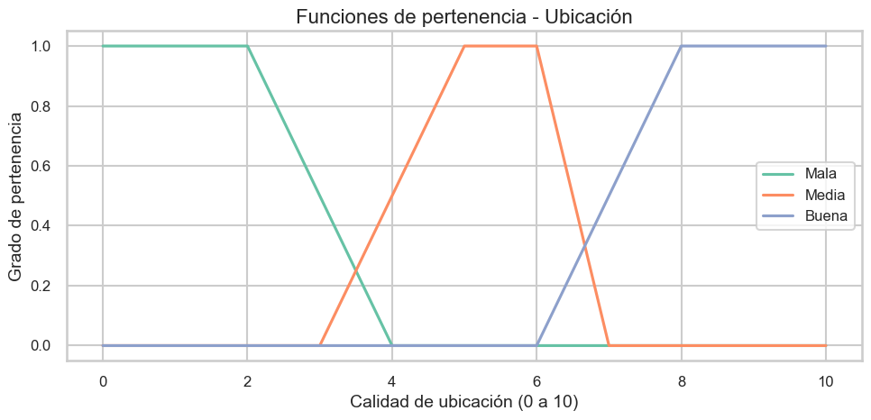

```python
# Funciones de pertenencia trapezoidales para "ubicación"
ubicacion['mala']  = fuzz.trapmf(ubicacion.universe, [0, 0, 2, 4])
ubicacion['media'] = fuzz.trapmf(ubicacion.universe, [3, 5, 6, 7])
ubicacion['buena'] = fuzz.trapmf(ubicacion.universe, [6, 8, 10, 10])

# Visualización
plt.figure(figsize=(10, 5))
plt.plot(ubicacion.universe, ubicacion['mala'].mf, label='Mala')
plt.plot(ubicacion.universe, ubicacion['media'].mf, label='Media')
plt.plot(ubicacion.universe, ubicacion['buena'].mf, label='Buena')
plt.title('Funciones de pertenencia - Ubicación')
plt.xlabel('Calidad de ubicación (0 a 10)')
plt.ylabel('Grado de pertenencia')
plt.legend()
plt.tight_layout()
plt.show()
```

### Funciones de pertenencia: Conveniencia de inversión

La variable **conveniencia de inversión** representa la salida del sistema, en una escala de 0 a 100. Usamos funciones de pertenencia sigmoidales para modelar dos categorías:

- **Baja**: función sigmoidal decreciente con parámetros b=40, c=−0.1
- **Alta**: función sigmoidal creciente con parámetros b=60, c=0.1

Esto permite transiciones suaves entre baja y alta conveniencia, sin cortes bruscos.

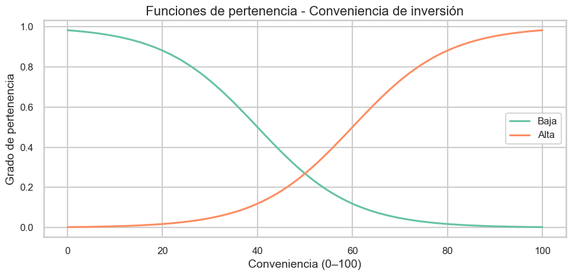

```python
# Funciones de pertenencia para la salida: conveniencia
# For sigmf, 'b' is the inflection point and 'c' is the slope
# Negative 'c' creates a decreasing function (for 'baja')
# Positive 'c' creates an increasing function (for 'alta')
conveniencia['baja'] = fuzz.sigmf(conveniencia.universe, b=40, c=-0.1)
conveniencia['alta'] = fuzz.sigmf(conveniencia.universe, b=60, c=0.1)

# Visualización
plt.figure(figsize=(10, 5))
plt.plot(conveniencia.universe, conveniencia['baja'].mf, label='Baja')
plt.plot(conveniencia.universe, conveniencia['alta'].mf, label='Alta')
plt.title('Funciones de pertenencia - Conveniencia de inversión')
plt.xlabel('Conveniencia (0–100)')
plt.ylabel('Grado de pertenencia')
plt.legend()
plt.tight_layout()
plt.show()
```

### Conclusión: Variables y funciones de pertenencia

En esta primera fase del diseño del sistema difuso hemos definido correctamente todas las variables necesarias:

- **Tres variables de entrada**: precio por m², rentabilidad esperada y calidad de la ubicación.
- **Una variable de salida**: conveniencia de inversión.

Para cada una de ellas hemos asignado conjuntos difusos apropiados, utilizando funciones de pertenencia trapezoidales o sigmoidales según el tipo de variable y las transiciones deseadas. Esta estructura nos permite capturar relaciones cualitativas y borrosas del mundo real, fundamentales en la toma de decisiones con incertidumbre.

Con estas definiciones completas, estamos listos para construir el motor de inferencia, mediante la formulación de reglas difusas que relacionan las variables de entrada con la salida.

## 4.Reglas difusas del sistema

A continuación definimos el conjunto de reglas que forman la base del sistema de inferencia difuso. Estas reglas combinan los valores lingüísticos de las variables de entrada y determinan si la conveniencia de inversión es alta o baja.

Reglas utilizadas:

1. Si el **precio es barato**, la **rentabilidad es alta** y la **ubicación es buena**, entonces la conveniencia es **alta**
2. Si el **precio es medio**, la **rentabilidad es alta** y la **ubicación es buena**, entonces la conveniencia es **alta**
3. Si el **precio es caro** y la **rentabilidad es baja**, entonces la conveniencia es **baja**
4. Si el **precio es caro** y la **ubicación es mala**, entonces la conveniencia es **baja**
5. Si la **rentabilidad es alta** y la **ubicación es media**, entonces la conveniencia es **alta**
6. Si la **rentabilidad es baja** y la **ubicación es mala**, entonces la conveniencia es **baja**

```python
# Definición de las reglas difusas
regla_1 = ctrl.Rule(precio['barato'] & rentabilidad['alta'] & ubicacion['buena'], conveniencia['alta'], label='Regla 1')
regla_2 = ctrl.Rule(precio['medio']  & rentabilidad['alta'] & ubicacion['buena'], conveniencia['alta'], label='Regla 2')
regla_3 = ctrl.Rule(precio['caro']   & rentabilidad['baja'],                   conveniencia['baja'], label='Regla 3')
regla_4 = ctrl.Rule(precio['caro']   & ubicacion['mala'],                      conveniencia['baja'], label='Regla 4')
regla_5 = ctrl.Rule(rentabilidad['alta'] & ubicacion['media'],                conveniencia['alta'], label='Regla 5')
regla_6 = ctrl.Rule(rentabilidad['baja'] & ubicacion['mala'],                 conveniencia['baja'], label='Regla 6')
```

## 5.Evaluación del sistema difuso

Una vez definidas las reglas, creamos el sistema completo utilizando `ControlSystem` y lo ejecutamos con `ControlSystemSimulation`. Evaluaremos el escenario propuesto en el enunciado, introduciendo los siguientes valores:

- **Precio**: 2200 USD/m²
- **Rentabilidad esperada**: 11%
- **Ubicación**: 8

El sistema devolverá un valor numérico entre 0 y 100 que representa el grado de conveniencia de invertir en ese inmueble.

```
Conveniencia de inversión: 74.29
```

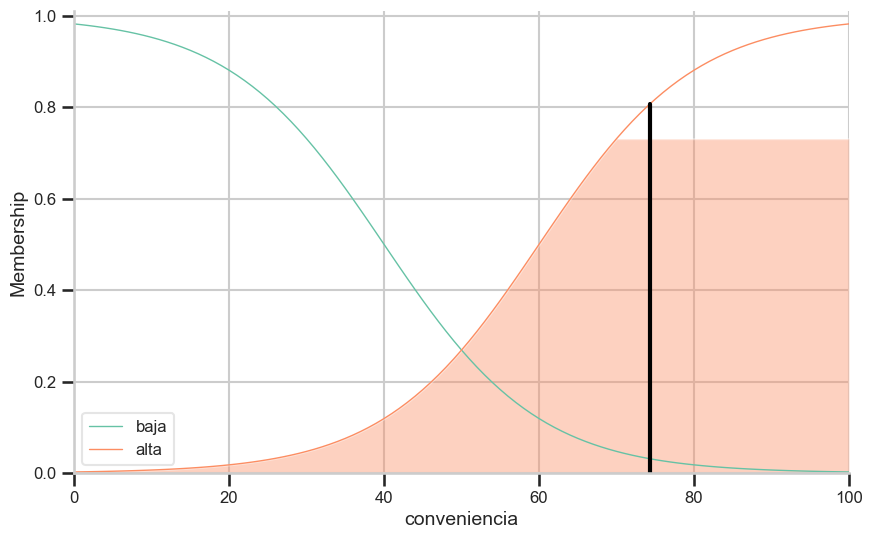

```python
# Crear el sistema de control difuso
sistema_control = ctrl.ControlSystem([
    regla_1, regla_2, regla_3, regla_4, regla_5, regla_6
])
simulador = ctrl.ControlSystemSimulation(sistema_control)

# Establecer los valores del escenario propuesto
simulador.input['precio'] = 2200
simulador.input['rentabilidad'] = 11
simulador.input['ubicacion'] = 8

# Ejecutar la inferencia difusa
simulador.compute()

# Mostrar el resultado
print(f"Conveniencia de inversión: {simulador.output['conveniencia']:.2f}")

# Visualización de la salida
conveniencia.view(sim=simulador)
```

### 6.Conclusión

El sistema de control difuso evaluó la conveniencia de inversión para el inmueble analizado con un resultado de **74.29 sobre 100**, lo que indica que se trata de una inversión **altamente recomendable** dadas sus condiciones de precio, rentabilidad y ubicación.